# Analysis Of U.S. Storm Data 2006-2011

tjs

Monday, April 20, 2015

#### SYNOPSIS:

This project studies the NOAA Storm Database of the United States for the years 2006-2011 and addresses two questions about severe weather events.

First, what types of events are most harmful to population health in the United States? The two aspects of personal health provided in the database (fatalities and injuries) were examined. For fatalities, the events that caused the largest numbers of fatalities (top 10%) are (in descending order) TORNADO, FLASH FLOOD, EXCESSIVE HEAT, RIP CURRENT, HEAT and LIGHTNING. For injuries, the events that caused the largest numbers of injuries (top 10%) are (in descending order) TORNADO, EXCESSIVE HEAT, THUNDERSTORM WIND, HEAT, LIGHTNING and WILDFIRE.

Second, what types of events have the most economic impact in the United States? The two economic factors provided in the database (property damage and crop damage) were examined. For property damage, the top 10% of costs resulted from (in descending order) FLOOD, TORNADO, HAIL, FLASH FLOOD, STORM SURGE/TIDE and THUNDERSTORM WIND. For crop damage, the top 10% of costs resulted from (in descending order) FLOOD, DROUGHT, HAIL, FROST/FREEZE, FLASH FLOOD and EXCESSIVE HEAT. The largest total cost were the results of (in descending order) FLOOD, TORNADO, HAIL, FLASH FLOOD, STORM SURGE/TIDE and THUNDERSTORM WIND.

#### Data Processing

```r
## download the Storm Data file
#download.file("https://d396qusza40orc.cloudfront.net/repdata%2Fdata%2FStormData.csv.bz2", "data/StormData.csv.bz2")

## download the documentation of the Storm Data file
# download.file("https://d396qusza40orc.cloudfront.net/repdata%2Fpeer2_doc%2Fpd01016005curr.pdf","data/StormDataDoc.pdf")

## download the FAQ file
# download.file("https://d396qusza40orc.cloudfront.net/repdata%2Fpeer2_doc%2FNCDC%20Storm%20Events-FAQ%20Page.pdf", "data/StormEvents-FAQ.pdf")

## read the data into R
data<-read.csv("data/StormData.csv")
print(dim(data))
```

```
## [1] 902297     37
```

2. The study used only 10 Of the 37 variables (columns) in the datafile, so the database was pared to include only those variables. An addditional variable containing the year the event began was added to the database.

```r
# Use 1986-1995 (10 years) data
keep<-c("BGN_DATE","COUNTYNAME", "STATE","EVTYPE","FATALITIES","INJURIES","PROPDMG","PROPDMGEXP","CROPDMG","CROPDMGEXP")
data_keep<-data[,keep]
data_keep$BGN_DATE<-as.Date(data_keep$BGN_DATE, "%m/%d/%Y")
require(lubridate)
data_keep$year<-year(data_keep$BGN_DATE)
print(head(data_keep,3))
```

```
##     BGN_DATE COUNTYNAME STATE  EVTYPE FATALITIES INJURIES PROPDMG
## 1 1950-04-18     MOBILE    AL TORNADO          0       15    25.0
## 2 1950-04-18    BALDWIN    AL TORNADO          0        0     2.5
## 3 1951-02-20    FAYETTE    AL TORNADO          0        2    25.0
##   PROPDMGEXP CROPDMG CROPDMGEXP year
## 1          K       0            1950
## 2          K       0            1950
## 3          K       0            1951
```

```r
data_years<-data_keep[data_keep$year > 2005,]
print(head(data_years,3))
```

```
##          BGN_DATE COUNTYNAME STATE  EVTYPE FATALITIES INJURIES PROPDMG
## 602045 2006-03-13    CULLMAN    AL TORNADO          0        0       0
## 602046 2006-03-13    CULLMAN    AL TORNADO          0        0       0
## 602047 2006-03-13    CULLMAN    AL TORNADO          0        0       0
##        PROPDMGEXP CROPDMG CROPDMGEXP year
## 602045                  0            2006
## 602046                  0            2006
## 602047                  0            2006
```

4. The first variable studied was the FATALITIES variable. A data.frame was extracted that contained only the event type (EVTYPE) and the total number of resulting fatalities (FATALITIES) caused by the storm. The events resulting in the top 10% of the fatalities was then extracted and sorted in decreasing order.

```r
require(stats)
sumDeathByFactor<-aggregate(FATALITIES ~ EVTYPE, sum, data = data_years,simplify=T)
sumDeathByFactor$EVTYPE<-as.character(sumDeathByFactor$EVTYPE)
print(quantile(sumDeathByFactor$FATALITIES))
```

```
##     0%    25%    50%    75%   100%
##   0.00   0.00   7.00  47.25 930.00
```

```r
Q90<-quantile(sumDeathByFactor$FATALITIES,.9)
Q90death<-sumDeathByFactor[sumDeathByFactor$FATALITIES > Q90,]
deathSort<-Q90death$FATALITIES
names(deathSort)<-Q90death$EVTYPE
deathSort<-sort(deathSort,decreasing=TRUE)
print(deathSort)
```

```
##        TORNADO    FLASH FLOOD EXCESSIVE HEAT    RIP CURRENT           HEAT
##            930            352            324            233            229
##      LIGHTNING
##            204
```

5. The second variable studied was the INJURIES variable. As was done for the previous variable, a data.frame was extracted that contained only the event type (EVTYPE) and the total number of resulting injuries (INJURIES) caused by the storm. The events resulting in the top 10% of the injuries was then extracted and sorted in decreasing order.

```r
require(stats)
sumHurtByFactor<-aggregate(INJURIES ~ EVTYPE, sum, data = data_years,simplify=T)
sumHurtByFactor$EVTYPE<-as.character(sumHurtByFactor$EVTYPE)
quantile(sumHurtByFactor$INJURIES)
```

```
##      0%     25%     50%     75%    100%
##     0.0     0.0    13.5   145.5 10600.0
```

```r
Q90<-quantile(sumHurtByFactor$INJURIES,.9)
Q90Hurt<-sumHurtByFactor[sumHurtByFactor$INJURIES > Q90,]
hurtSort<-Q90Hurt$INJURIES
names(hurtSort)<-Q90Hurt$EVTYPE
hurtSort<-sort(hurtSort,decreasing=TRUE)
print(hurtSort)
```

```
##           TORNADO    EXCESSIVE HEAT THUNDERSTORM WIND              HEAT
##             10600              1873              1400              1222
##         LIGHTNING          WILDFIRE
##              1168               517
```

6. The next variables studied dealt with property damage (PROPDMG and PROPDMGEXP). The interpretation of these variables was not as straight forward as the first two variables. In particular, a decision had to be made on how to use the PROPDMGEXP variable. A search failed to reveal a definitive answer to how to use this variable. The first step in the decision was to examine its values.

```r
levels(data_years$PROPDMGEXP)
```

```
##  [1] ""  "-" "?" "+" "0" "1" "2" "3" "4" "5" "6" "7" "8" "B" "h" "H" "K"
## [18] "m" "M"
```

One guess for the purpose of this variable is as a multiplier for the value in the variable PROPDMG. This would make sense for the letters: ‘h’ or ‘H’ for 100, ‘K’ for 1,000 and ‘m’ or ‘M’ for million. A blank or ‘-’ would indicate none (multiply by 1). A ‘?’ would indicate unknown. A ‘+’ would indicate a little more than the value in PROPDMG. But what about the integers? A study of NOAA storm data given by years did not add clarity. For example, a row from the data used reads

```
##           BGN_DATE         COUNTYNAME              STATE
##     7/25/1995 0:00              BACON                 GA
##             EVTYPE         FATALITIES           INJURIES
## THUNDERSTORM WINDS                  0                  0
##            PROPDMG         PROPDMGEXP            CROPDMG
##               50.0                  0                  0
##         CROPDMGEXP
##                  _
```

while the data from the *1995-07 NOAA Storm Data Select Publications* (http://www.ncdc.noaa.gov/IPS/sd/sd.html?_finish=0.20716401179117683) reads:

```
##           Location               Date           Standard
##       Bacon County                 25            1732EST
##            (Miles)            (Yards)             Killed
##                  _                  _                  0
##            Injured           Property              Crops
##                  0                500                  0
## Character of Storm
## Thunderstorm Winds
```

Very confusing, how does a $500 cost become a 50.0 0 pair! The choice most likely seemed to be to replace *n* by 10^*n*, inspite of the fact that the replacement does not work in this case.

```r
replaceValues<-c("h"="100","H"="100","k"="1000","K"="1000","m"="1000000","M"="1000000","B"="1000000000","+"="1","-"="1","?"="1")
replaceValues<-c(replaceValues,"0"="1","1"="10","2"="100","3"="1000","4"="10000","5"="100000","6"="1000000","7"="10000000","8"="100000000")
print(noquote(replaceValues))
```

```
##          h          H          k          K          m          M
##        100        100       1000       1000    1000000    1000000
##          B          +          -          ?          0          1
## 1000000000          1          1          1          1         10
##          2          3          4          5          6          7
##        100       1000      10000     100000    1000000   10000000
##          8
##  100000000
```

```r
require(plyr)
data_years$PROPDMGEXP<-as.character(revalue(data_years$PROPDMGEXP, replaceValues))
data_years$PROPDMGEXP[data_years$PROPDMGEXP == ""]<-"1"
data_years$PROPDMGEXP<-as.numeric(data_years$PROPDMGEXP)
data_years$PROPDMGEXP[is.na(data_years$PROPDMGEXP)]<-1
summary(data_years$PROPDMGEXP)
```

```
##      Min.   1st Qu.    Median      Mean   3rd Qu.      Max.
## 1.000e+00 1.000e+03 1.000e+03 4.537e+04 1.000e+03 1.000e+09
```

Once the replacements were made, the two variables were combined into a new variable by multiplying the PROPDMG with the replaced values now in PROPDMGEXP.

```r
data_years$PropTot<-data_years$PROPDMG * data_years$PROPDMGEXP
summary(data_years$PropTot)
```

```
##      Min.   1st Qu.    Median      Mean   3rd Qu.      Max.
## 0.000e+00 0.000e+00 0.000e+00 5.972e+05 2.000e+03 1.150e+11
```

Now the top 10% of the property damage costs could be found and sorted.

```r
require(stats)
sumPropTotByFactor<-aggregate(PropTot ~ EVTYPE, sum, data = data_years,simplify=T)
sumPropTotByFactor$EVTYPE<-as.character(sumPropTotByFactor$EVTYPE)
quantile(sumPropTotByFactor$PropTot)
```

```
##           0%          25%          50%          75%         100%
##            0       488300      7289000    252273803 130485411240
```

```r
Q90<-quantile(sumPropTotByFactor$PropTot,.9)
Q90PropType<-sumPropTotByFactor[sumPropTotByFactor$PropTot > Q90,]
propSort<-Q90PropType$PropTot
names(propSort)<-Q90PropType$EVTYPE
propSort<-sort(propSort,decreasing=TRUE)
print(propSort)
```

```
##             FLOOD           TORNADO              HAIL       FLASH FLOOD
##      130485411240       15381596740        7399567600        7177267260
##  STORM SURGE/TIDE THUNDERSTORM WIND
##        4641188000        3382654440
```

7. The last variables studied dealt with crop damage (CROPDMG and CROPDMGEXP). The interpretation of these variables was done the same as that of the two previous variables (PROPDMG and PROPDMGEXP)

```r
require(plyr)
data_years$CROPDMGEXP<-as.character(revalue(data_years$CROPDMGEXP, replaceValues))
data_years$CROPDMGEXP[data_years$CROPDMGEXP == ""]<-"1"
data_years$CROPDMGEXP<-as.numeric(data_years$CROPDMGEXP)
data_years$CROPDMGEXP[is.na(data_years$CROPDMGEXP)]<-1
data_years$CropTot<-data_years$CROPDMG * data_years$CROPDMGEXP
summary(data_years$CropTot)
```

```
##     Min.  1st Qu.   Median     Mean  3rd Qu.     Max.
## 0.00e+00 0.00e+00 0.00e+00 3.48e+04 0.00e+00 1.00e+09
```

Then the top 10% of the crop damage costs was found and sorted.

```r
require(stats)
sumCropTotByFactor<-aggregate(CropTot ~ EVTYPE, sum, data = data_years,simplify=T)
sumCropTotByFactor$EVTYPE<-as.character(sumCropTotByFactor$EVTYPE)
quantile(sumCropTotByFactor$CropTot)
```

```
##         0%        25%        50%        75%       100%
##          0          0      10000   28123975 2981275000
```

```r
Q90<-quantile(sumCropTotByFactor$CropTot,.9)
Q90CropType<-sumCropTotByFactor[sumCropTotByFactor$CropTot > Q90,]
cropSort<-Q90CropType$CropTot
names(cropSort)<-Q90CropType$EVTYPE
cropSort<-sort(cropSort,decreasing = TRUE)
print(cropSort)
```

```
##          FLOOD        DROUGHT           HAIL   FROST/FREEZE    FLASH FLOOD
##     2981275000     2801241000     1001730000      943741000      736955000
## EXCESSIVE HEAT
##      492400000
```

8. The final step in the analysis was to obtain the total cost by adding the property damage costs and the crop damage costs. This was stored and analyzed as a new variable (totalCost).

```r
totalCost<-sumCropTotByFactor$CropTot + sumPropTotByFactor$PropTot
names(totalCost)<-sumPropTotByFactor$EVTYPE
totDamage<-sort(totalCost,decreasing=TRUE)
head(totDamage,6)
```

```
##             FLOOD           TORNADO              HAIL       FLASH FLOOD
##      133466686240       15491243740        8401297600        7914222260
##  STORM SURGE/TIDE THUNDERSTORM WIND
##        4642038000        3780985440
```

#### Results

1. The types of events are most harmful to population health in the U.S. in the time period 2006-2011 are as follows.

The storms that caused the most fatalities are (in decreasing order): TORNADO (930), FLASH FLOOD (352), EXCESSIVE HEAT (324), RIP CURRENT (233), HEAT (229) and LIGHTNING (204).

The storms that caused the most injuries are (in decreasing order): TORNADO (10,600), EXCESSIVE HEAT (1,873), THUNDERSTORM WIND (1,400), HEAT, (1,222), LIGHTNING, (1,168) and WILDFIRE (517)

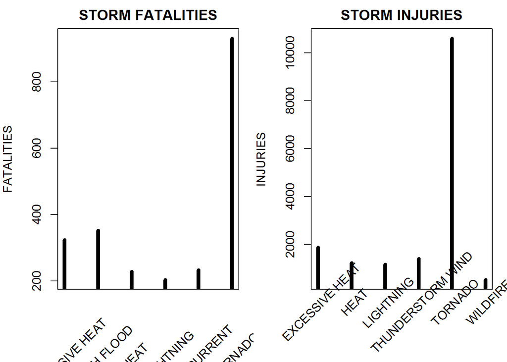

```r
par(mfrow = c(1, 2), mar = c(5, 4, 2, 1), xaxt="n")
# # plot fatalities
lablist<-as.vector(Q90death$EVTYPE)
plot(Q90death$FATALITIES,type="h",lwd=5,xlab="",ylab="FATALITIES",main="STORM FATALITIES")
axis(1,at=1:6,labels=F)
text(1:6,labels=lablist,srt=45,pos=1,xpd=T)
# # plot injuries
lablist<-as.vector(Q90Hurt$EVTYPE)
plot(Q90Hurt$INJURIES,type="h",lwd=5,xlab="",ylab="INJURIES",main="STORM INJURIES")
axis(1,at=1:6,labels=F)
text(1:6,labels=lablist,srt=45,pos=1,xpd=T)
```

2. The types of events are had the most economic effect in the U.S. in the time period 2006-2011 are as follows.

The storms that caused the most property damage are (in decreasing order): FLOOD ($130,485,411,240), TORNADO ($15,381,596,740), HAIL ($7,399,567,600), FLASH FLOOD ($7,177,267,260), STORM SURGE/TIDE ($4,641,188,000) and THUNDERSTORM WIND (3,382,654,440).

The storms that caused the most crop damage are (in decreasing order): FLOOD (2,981,275,000), DROUGHT (2,801,241,000), HAIL (1,001,730,000), FROST/FREEZE (943,741,000), FLASH FLOOD (736,955,000) and EXCESSIVE HEAT (492400000).

The storms that caused the most total damage, both property and crops, are (in decreasing order): FLOOD (133,466,686,240) , TORNADO (15,491,243,740), HAIL (8,401,297,600), FLASH FLOOD (7,914,222,260), STORM SURGE/TIDE (4,642,038,000) and THUNDERSTORM WIND (3,780,985,440).

```r
par(mfrow = c(2, 2), mar = c(5, 4, 2, 1), xaxt="n")
head(Q90PropType)
```

```
##               EVTYPE      PropTot
## 13       FLASH FLOOD   7177267260
## 14             FLOOD 130485411240
## 18              HAIL   7399567600
## 40  STORM SURGE/TIDE   4641188000
## 42 THUNDERSTORM WIND   3382654440
## 43           TORNADO  15381596740
```

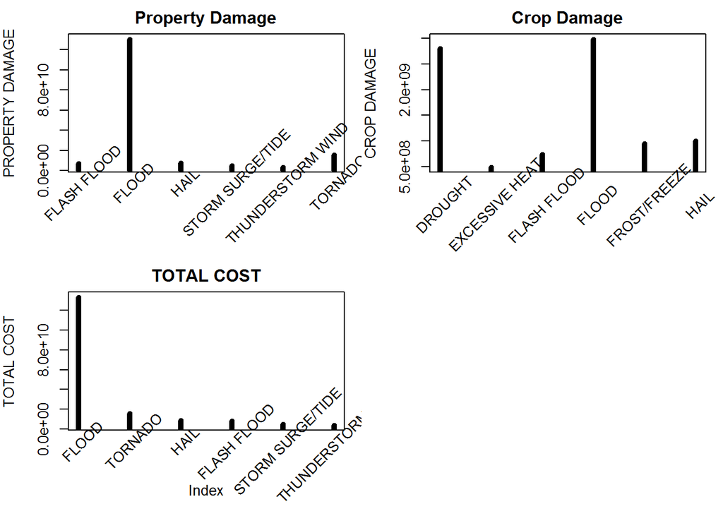

```r
# property damage
lablist<-as.vector(Q90PropType$EVTYPE)
plot(Q90PropType$PropTot,type="h",lwd=5,xlab="",ylab="PROPERTY DAMAGE", main="Property Damage")
axis(1,at=1:6,labels=FALSE)
text(1:6,labels=lablist,srt=45,pos=1,xpd=T)
# crop damage
lablist<-as.vector(Q90CropType$EVTYPE)
plot(Q90CropType$CropTot,type="h",lwd=5,xlab="",ylab="CROP DAMAGE",main="Crop Damage")
axis(1,at=1:6,labels=F)
text(1:6,labels=lablist,srt=45,pos=1,xpd=T)
# total
#par(1,1)
plot(totDamage[1:6],type='h',lwd=5,main="TOTAL COST", ylab="TOTAL COST")
lablist<-as.vector(names(totDamage[1:6]))
axis(1,at=1:6,labels=F)
text(1:6,labels=lablist,srt=45,pos=1,xpd=T)
```